# HomeWork 1

## by Mohga Soliman Emam

> **In this homework i solved five exercises. I will mention them briefly down below.**

```python
from PIL import Image, ImageDraw
```

### HW1

**In this exercise I wanted to focus on implementing a sorting algorithm. I chose the insertion sort algorithm since it's very popular, mentioned in the book and i wanted to experience a bit with it. The insertion sort can be enhanced greately. I woked on it in my bachelor's algorithms course and my main focus was to enhance its runtime.**

> - First i wanted to make sure it works perfectly and correctly so i generated a random sample of 100 numbers and sorted it out using the insertion sort that i have created.
> - Second I ran into the problem of checking whether the sorted output is 100% correct or not. It's hard to check using the normal eye so I created a list then stored the sorted list using the built in sort function.
> - Then I compared the two together to make sure that the insertion sort algorithm is correct(I also checked my algorithm with repeated numbers and it worked perfectly without any errors).
> - After knowing that the algorithm is correct i need to move to the next step, generate a function from the [0, MAX_INT] value in the python language but since I'm using python 3 there is actually no limit. In Python 3 so the plain int type is unbounded with python 3 we can calculate googal number that we mentioned in the lecture.
> - The next step for me was to Investigate the variability in runtime in my insertion sort algoritm and how I implemented that was like the following:
>   > - I created a loop that will iterate 200 times and get the exact time before the implementation of insertion sort algorithm, implement the insertion sort algorithm on the random numbers, get the time after the algorithm implementation and store the beginning and ending time in two separate lists.
>   > - During the implementation i ran into the problem that i needed to store the beginning and ending time into lists but we can't append floats into lists in python3 so how can we work around this problem was by converting these values into strings and append them and at the end convert the entire list into floats once again.
>   > - I also wanted to compute the difference between the beginning and ending time so I can use that time later on in the comparison between the different inputs run times.
>   > - Finally i plotted the insertion sort algorithms runtime

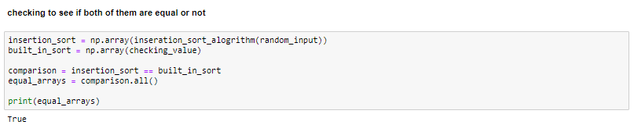

```python
Image.open("2.PNG")
```

Here I'm checking the list sorted using the insertion sort algorithm with the list sorted by the built-in sort function.

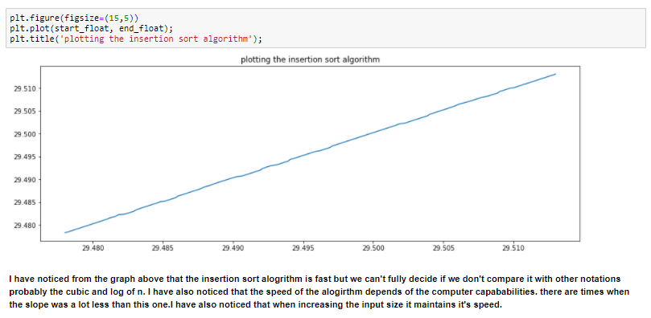

```python
Image.open("1.PNG")
```

This is the implementation of the insertionsort algorithm runtime. we see that it's not really that fast but to make sure we need to check other cases not just this case. For that purpose i repeated the above logic on bigger and bigger numbers.

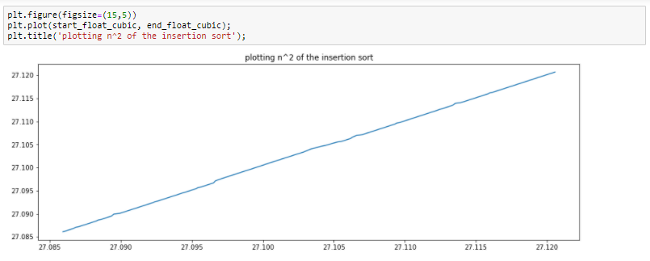

```python
Image.open("3.PNG")
```

In this plot i increased the input by square root and repeated the above steps. and here we see that the runtime is slower than the pervious case

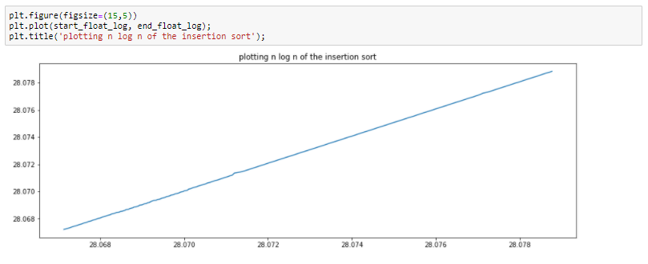

```python
Image.open("4.PNG")
```

In this plot i calculated the n log n of the input and wanted to plot the runtime.

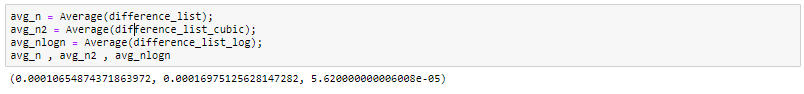

```python
Image.open("5.PNG")
```

> Finally i wanted to compare between the averga of all the runtimes. I was very specific on the concept of choosing the average to compare between the three runtimes because with the average we get the true representation of the data. I also wanted to compare between the mean (the mean of the runtime will get us the distribution of the runtime values) but i will implement that in the next HW. We also see that the runtime of (n log n) is the smallest followed by the runtime of (n) and finally the runtime of (n^2) which is expected.

**Next, I was really intrested in the effects of the runtime when we increase N. For that part i decided to go with two ways.**

> 1. Choosing a list of values(random values irrelevant to the original random values) and work with it
> 2. Choosing a list of values(random values from the original random values) so i can be able to plot them and get the difference between the runtime of the both of them.

First let's follow the first logic: First I created a new random list then i increased the value to the power of two. then i repeated the steps above(calculating the runtime, the differece and plotting the runtime).

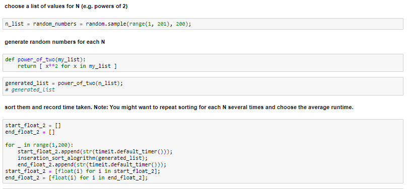

```python
Image.open("6.PNG")
```

Second I wanted to take the list from the original list so we can compare the runtime of the two together and our conclusion will be accurate enough. So we sliced the first 50 numbers and calculated the power two of the list then repeated the process of computing the runtime, differece and plotting and we observed the results.

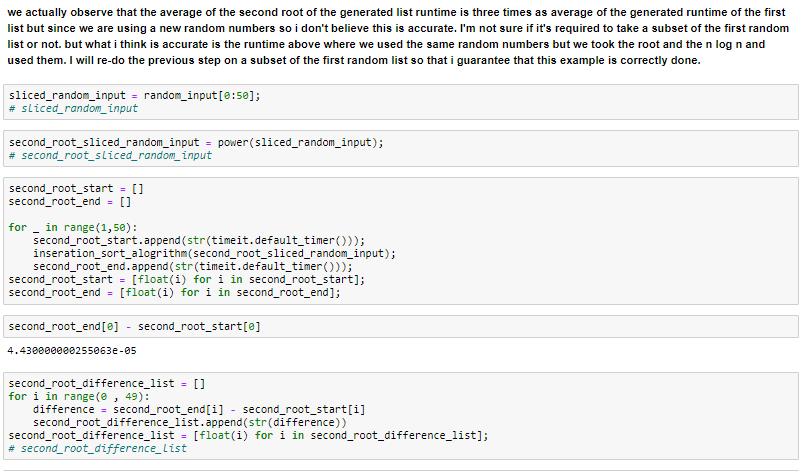

```python
Image.open("7.PNG")
```

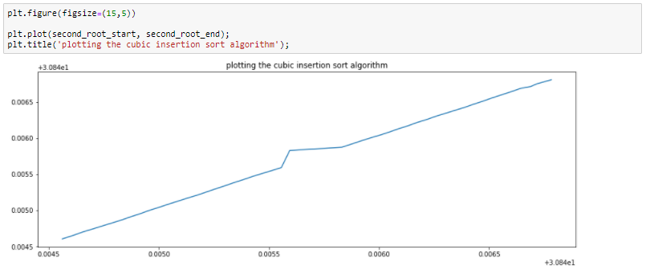

```python
Image.open("8.PNG")
```

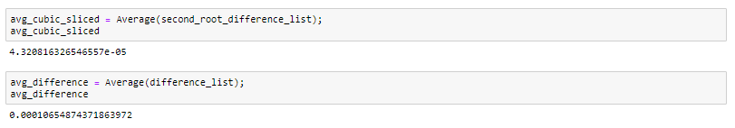

```python
Image.open("9.PNG")
```

### Let's make a small summary of what we focused on in this excersise

**we might want to repeat sorting for each N several times and choose the average runtime due to the following reasons:**

> 1. Because we are working with random numbers so we need to get the repeat the process more than once to make sure that the result that we are getting will apply to all the cases not just the one we are using.
> 2. By choosing the average we avoided incorrect statistical sampling because when we took the average we took a value that resembles all the sample. we didn't take the min, max or an outlier.

> The reason why I think insertion sort is a good algorithm and used it is because it's very popular algorithm, i wanted to experience with an alogrithm that was mentioned in the book and i really enjoy implementing inseration sort. It has a lot of space to enhace its performance easily.

> Also an important thing that I need to mention is that I have used two types of N in this part of the example because i wasn't sure what N is required. It makes sense to use a subset from the original N to be able to see the chaneg between the runtime differnece of the two implementation. But again we can also experience with a new N and i wasn't sure of what's required to be honst and i loved to experience a bit.

> Regarding the number of times I have repeated this experiment is 200 times for each N and 50 times for the subset of N. I felt that it's important to repeat it because with repeating the experiment more than once we get more accurate results.

> We have actually have figured out some amazing results from this experiment After plotting the O(N) , O(N^2) , O(N log N) we actually see that
> > 1. The runtime of (n log n) is always the smallest.
> > 2. The runtime of (n) follows the runtime of (n log n).
> > 3. The runtime of (n^2) is actually the largest.

### HW2

In this exercise we will measure the runtime of the sort algorithm. by repeating the process of storing the beginning and ending times in lists then calculate the differece so we can get the average of the difference and measure the runtime with it.

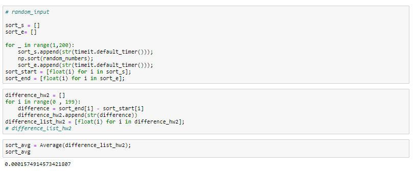

```python
Image.open("10.PNG")
```

Then we will plot the runtime of the built-in sort algorithm. and we can actually see that it maintain its runtime until it starts to increase rapidly in 0.063

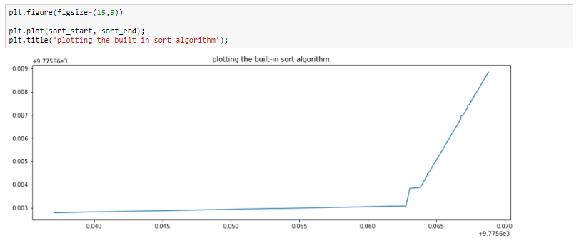

```python
Image.open("11.PNG")
```

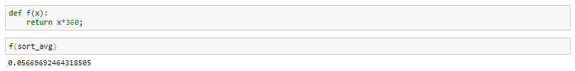

```python
Image.open("12.PNG")
```

### HW3

**In this exercise, I will measure how many integers (N) I can roughly sort in 1 minute with both the insertionsort algorithm that I have created and the built-in sorting algorithm.**

First I have created two algorithms each one of them will take the number of seconds and calculate the number of numbers that it can sort. What I used here is a list of 200 random numbers. with each iteration the function will sort 200n number.

In the image shown below we can see the built-in sort algorithm has measured 12009 integer number. This algorithm takes the number of seconds and calculate the time elapsed then multiply it with 200 because the list we are working on has the 200 integer number.

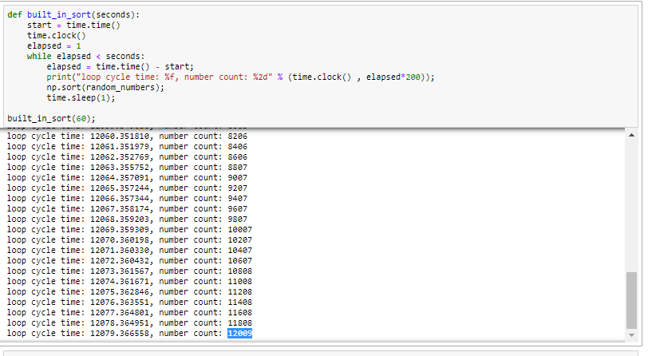

```python
Image.open("13.PNG")
```

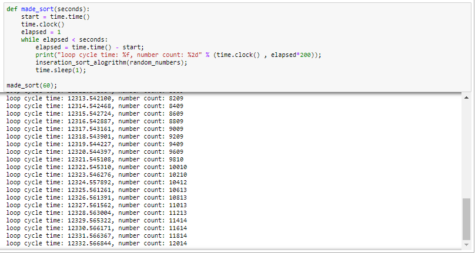

```python
Image.open("14.PNG")
```

Let's inspect the sort built-in function first. In the experiment we observe that it actually counted 12064 number which is higher than the pervious number 12009

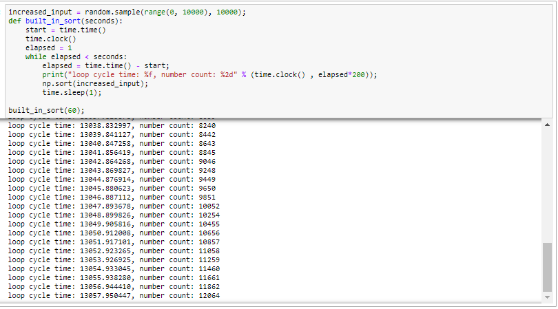

```python
Image.open("15.PNG")
```

Now let's inspect the my insertion function. In the experiment we observe that it actually counted 12034 number which is higher than the pervious number 12014 but still lower than the built-in 100N.

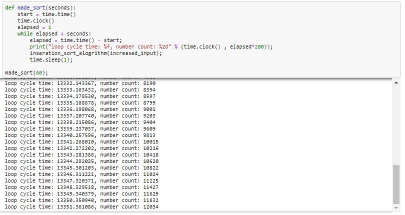

```python
Image.open("16.PNG")
```

**In conclusion we can actually say that with larger N the built-in sort algorithm runs faster than my insertion sort algorithm but in the average case my alogrithm runs faster. I think that comes back to the fact that the built-in sort algorithm uses the TIMSORT algorithm in the backend so it does improve the performace of its runtime better than the normal insertion sort algorithm.**

### HW4

In this exercise we will prove that f(n) = Theta(g(n)). Our strategy to solve this exercise is to finding suitable c1, c2 and n.

> In order to prove the theta notation we need to prove the big O notation and the big omega notation. so in code we need to prove that: c1(n^3+n^2) <= 3n^3+n <= c2(n^3+n^2)

> In the below image we see the strategy that i used to prove the that f(n) = Theta(g(n)).
> 1. First I wanted to generate two lists of random integers to represent c1, c2
> 2. Second I create a function that returns the values of the c1, n and c2 only when these values achieve the theta concept. In this function I used the equations provided in the exercise.
> 3. Third I have created a loop that loops the c1_random_input amount of times(which is the same as c2_random_input) amount of times.
> 4. In this function we are storing the values that achieve the big theta in dedicated lists.

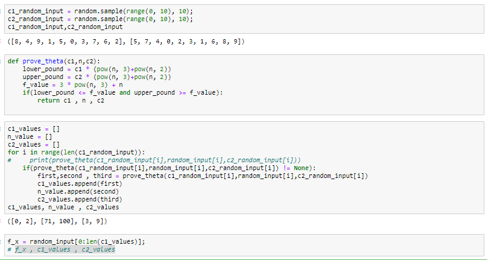

```python
Image.open("17.PNG")
```

[figure not shown]

```python
Image.open("18.PNG")
```

### HW5

> How I handled this is I created a new function to generate samples and multiply them by 10. Then I created the quicksort alogrithm. Finally I created a loop that will call the generate sample function to generate a new random number list then we sort them and the goal of this loop is to see what is how much N is already infeasible to test all permutations on my laptop.

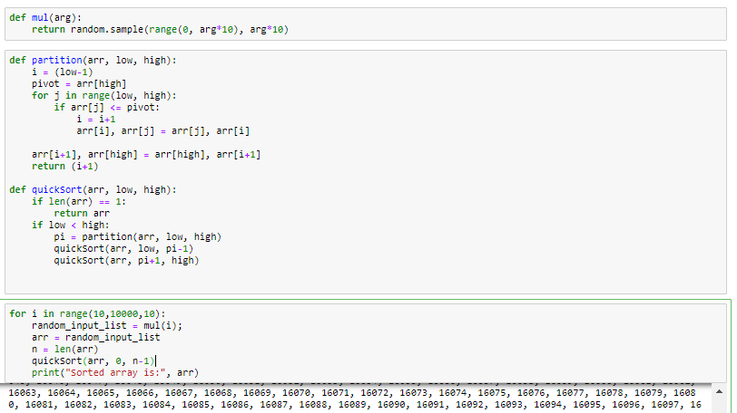

```python
Image.open("19.PNG")
```

> **on my laptop any numbers bigger than 100000 are not infeasible. I have tried several times but it always end up with errors.**

> In conclusion I know that any numbers bigger than 100000 are not infeasible on my laptop. I have also created random permutation of N values using the for loop that uses the multiplication function (mul) that generate the random numbers and multiply it by 10.

> we can scramble fully the ordered input using the shuffle function. The shuffle function is a really useful function to disorganize or disarray the input. A really important note to keep in mind is that the shuffle function replaces the existing list, it doesn't create a copy of it rather than taking the existing list and shuffle it.